# Mathan Brewer JSON Vignette

Mathan Brewer

10/14/2019

#Background

JSON stands for JavaScript Object Notation, and it is a format for structured data that is easy to access, read, write and organize. It takes multiple peices on an observation and store this in a string. It then can take multpile strings to store them as an array. This allows the data to be stored in a simplier manner, so that it is more efficient in terms of reading, writing and querying. For this example we will be looking at wine data from kaggle found at [this website](https://www.kaggle.com/zynicide/wine-reviews#winemag-data-130k-v2.json). This dataset contains the point value of the wine, title, a description, the name and twitter of the taster, the price in dollars, designation, variety, and information about the winery.

#Data and Packages

##JSON Structure

FIrst we will look at the structure of the JSON data. Below is the JSON code for the first observation. The first thing we notice about this data is the bracket, this signifies the begining of a new observations. Next, we have the quotation marks around different values such as “points” and “Nicosia 2013 Vulk/u00e0 Bianco (Etna)”, this is showing when a particular value starts and ends. The variables and the individual values are seperated by a colon in this notation. For example “pionts” : “87”, this is telling us that the point for this wine was 87. The final part we have is the comma that is between values within quotations. For example “87”, “title”, this is separating two different observations. You may see commas inside of a quotation, but this is only a part of a value of an observation, like a list.

{“points”: “87”, “title”: “Nicosia 2013 Vulk/u00e0 Bianco (Etna)”, “description”: “Aromas include tropical fruit, broom, brimstone and dried herb. The palate isn’t overly expressive, offering unripened apple, citrus and dried sage alongside brisk acidity.”, “taster_name”: “Kerin O/u2019Keefe”, “taster_twitter_handle”: “@kerinokeefe”, “price”: null, “designation”: “Vulk/u00e0 Bianco”, “variety”: “White Blend”, “region_1”: “Etna”, “region_2”: null, “province”: “Sicily & Sardinia”, “country”: “Italy”, “winery”: “Nicosia”}

##Read Into R

To begin reading this data into R we first need to install a package to deal with this type of data. I choose to use “jsonlite” to read in this data into R. I used this package because it seemed to be the easiest to read in the data as a data frame using and output the data as a JSON. I used the fromJSON to read in the JSON data as a data frame.

```r
install.packages("jsonlite")
library(jsonlite)
winedata<-fromJSON("winemag-data-130k-v2.json")
wineJSON<- toJSON(winedata)
```

Below are the first ten observations of the data frame.

```r
head(winedata, n =10)
```

```
##    points
## 1      87
## 2      87
## 3      87
## 4      87
## 5      87
## 6      87
## 7      87
## 8      87
## 9      87
## 10     87
##                                                                                  title
## 1                                                    Nicosia 2013 Vulkà Bianco  (Etna)
## 2                                        Quinta dos Avidagos 2011 Avidagos Red (Douro)
## 3                                        Rainstorm 2013 Pinot Gris (Willamette Valley)
```

[output cut: 62 more lines]

For this data we wanted to do a few things to make it more useful to a consumer, so the first thing I am going to do is add a new variable for someone to find the best bang for their buck to say. We are going to add in points per dollar.

```r
winepoints<-as.numeric(winedata$points)
pointperdollar<-as.data.frame(winepoints/winedata$price, na.rm = TRUE)
winedatanew<- as.data.frame(c(winedata,pointperdollar))
winedatanew$country<-as.character(winedatanew$country)
winedatanew$price<-as.numeric(as.character(winedatanew$price))
winedatanew$points<-as.numeric(as.character(winedatanew$points))
head(winedatanew, n =10)
```

```
##    points
## 1      87
## 2      87
## 3      87
## 4      87
## 5      87
## 6      87
## 7      87
## 8      87
## 9      87
## 10     87
##                                                                                  title
## 1                                                    Nicosia 2013 Vulkà Bianco  (Etna)
## 2                                        Quinta dos Avidagos 2011 Avidagos Red (Douro)
## 3                                        Rainstorm 2013 Pinot Gris (Willamette Valley)
```

[output cut: 62 more lines]

Another thing we are going to do is create a function to help us do some price conversions. If you look at the first wine in our data you will notice the country of origin is Italy, and since this country and many of the other countries in this data uses euros as their currency, we are going to create a function to convert the dollar to euros.

```r
europrice<- function(x){
            newvalue<-x*.90
            return(newvalue)
}
```

```r
europrice(14)
```

```
## [1] 12.6
```

#Data Analysis

For many of us who are in the US, that maybe the data we are more concerned with so we are going to create a new dataset for just the wine in the US.

```r
USdata<-filter(winedatanew, winedatanew$country == "US")
```

##Table

Next we will look at the counts by state.

```r
kable(table(droplevels(USdata$province)))
```

| Var1 | Freq |
| --- | --- |
| America | 95 |
| Arizona | 41 |
| California | 36247 |
| Colorado | 68 |
| Connecticut | 3 |
| Hawaii | 1 |
| Idaho | 192 |
| Illinois | 6 |
| Iowa | 4 |
| Kentucky | 1 |
| Massachusetts | 7 |
| Michigan | 114 |
| Missouri | 33 |
| Nevada | 4 |
| New Jersey | 8 |
| New Mexico | 45 |
| New York | 2688 |
| North Carolina | 23 |
| Ohio | 12 |
| Oregon | 5373 |
| Pennsylvania | 18 |
| Rhode Island | 1 |
| Texas | 94 |
| Vermont | 3 |
| Virginia | 777 |
| Washington | 8639 |
| Washington-Oregon | 7 |

##ScatterPlot

You will notice that California, as expected is much larger than the others, but does that make it the best place for wine. We are going to look at a scatterplot of the data to maybe see which state has the best points for dollar wine.

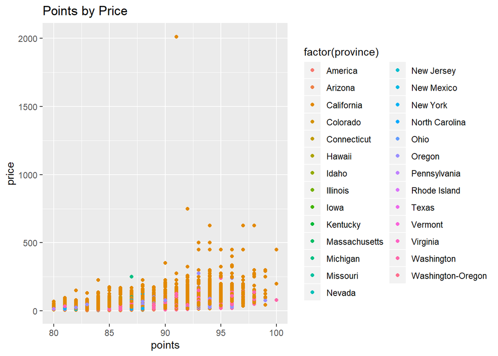

```r
pointbyprice <- ggplot(USdata, aes(x= points, y = price, colour = factor(province)))

pointbyprice + geom_point(aes(colour = factor(province)))+labs( title = "Points by Price")
```

##Virgina and Washington

It looks like by this that the best points for dollar wine is possibly from California, but it also could be from maybe Virgina or Washington too. So we are going to look at the lowest point per dollar in each state.

```r
USdata %>%
  group_by(province) %>%
  slice(which.min(winepoints.winedata.price))->mindata
mindata%>%select(province, winepoints.winedata.price)->statemins
statemins<-as.data.frame(statemins)
head(statemins, n = 27)
```

```
##             province winepoints.winedata.price
## 1            America                1.18666667
## 2            Arizona                1.59259259
## 3         California                0.04520616
## 4           Colorado                0.86000000
## 5        Connecticut                4.20000000
## 6             Hawaii                3.10714286
## 7              Idaho                1.63636364
## 8           Illinois                2.10000000
## 9               Iowa                4.05000000
## 10          Kentucky                2.37142857
## 11     Massachusetts                2.30555556
## 12          Michigan                0.34800000
## 13          Missouri                2.15000000
## 14            Nevada                1.12000000
## 15        New Jersey                2.30555556
## 16        New Mexico                2.18421053
## 17          New York                0.70400000
## 18    North Carolina                1.76000000
## 19              Ohio                4.94117647
## 20            Oregon                0.33818182
## 21      Pennsylvania                1.84782609
## 22      Rhode Island                3.60000000
## 23             Texas                1.08750000
## 24           Vermont                1.88888889
## 25          Virginia                0.90000000
## 26        Washington                0.39583333
## 27 Washington-Oregon                3.00000000
```

##Washington and Oregon

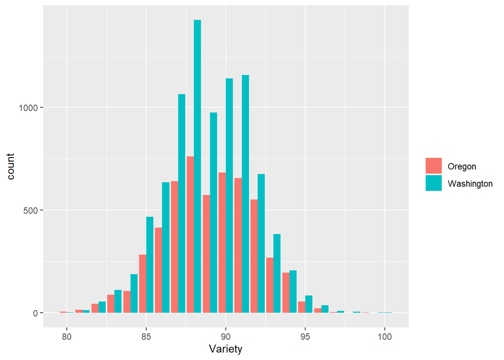

```r
washandorg<-filter(USdata, USdata$province %in% c("Washington", "Oregon"))
points <- ggplot(data = washandorg, aes(x = points))
points + geom_bar(aes( fill = as.factor(province)), position = "dodge") + xlab("Variety") +
  labs( fill = " ")
```

The spread looks similar, in this way, but lets compare them another way.

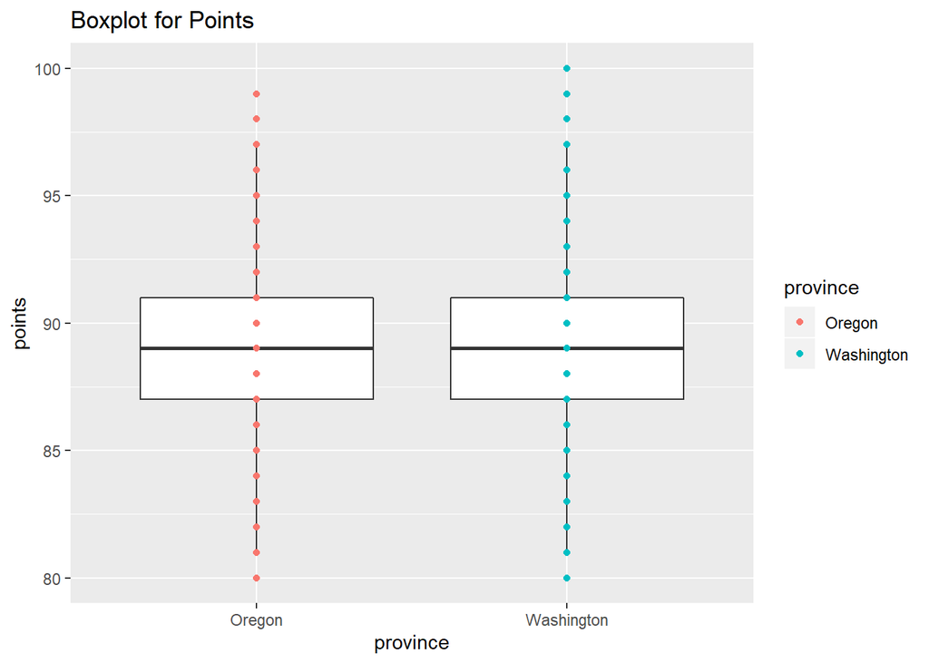

```r
statevpoints <- ggplot(washandorg, aes(x = province, y = points))
statevpoints + geom_boxplot() + geom_point(aes(colour = province))+labs( title = "Boxplot for Points")
```

Well since we can’t clearly see a better wine state based on graphs, then lets look to see if maybe some number can tell us something.

```r
summarize(group_by(washandorg, province), mean = mean(points), StdDev= sd(points))
```

```
## # A tibble: 2 x 3
##   province    mean StdDev
##   <fct>      <dbl>  <dbl>
## 1 Oregon      89.1   2.80
## 2 Washington  88.9   2.65
```

Wow those numbers are really close. The next step we could take is to do a hypothesis test, but I’ll leave that up to you.